# NYPD Shooting Data Report

Justin Thorpe

2024-09-24

### Introduction

Shootings are a problem nationwide. To better understand where this violence is coming from, we have to look at the data at a local level to get a clearer picture and help ensure police and legislators can respond to or even prevent such tragedies. By using statistical data, we can identify trends and patterns to generate insights and help in decision making to help solve this issue.

### Importing the Dataset and libraries

```r
library(tidyverse)
```

```r
library(dplyr)
library(lubridate)
library(ggplot2)

urls <- "https://data.cityofnewyork.us/api/views/833y-fsy8/rows.csv?accessType=DOWNLOAD"
NYPD_Shooting_Incident_Data_Historic <- read.csv(urls)
```

### Data Cleaning

Remove irrelevant columns, and rename the rest. Display first five rows of the table.

```r
NYPD_Shooting_Data = subset(NYPD_Shooting_Incident_Data_Historic, select = -c(LOC_OF_OCCUR_DESC, JURISDICTION_CODE, X_COORD_CD, Y_COORD_CD, Latitude, Longitude, Lon_Lat))

NYPD_Shooting_Data <- NYPD_Shooting_Data %>% rename(Incident = INCIDENT_KEY, Date = OCCUR_DATE, Time = OCCUR_TIME, Borough = BORO, Precinct = PRECINCT, Location_Class = LOC_CLASSFCTN_DESC, Location_Description = LOCATION_DESC, Murder_Flag = STATISTICAL_MURDER_FLAG, Perp_Age_Group = PERP_AGE_GROUP, Perp_Sex = PERP_SEX, Perp_Race = PERP_RACE, Victim_Age_Group = VIC_AGE_GROUP, Victim_Sex = VIC_SEX, Victim_Race = VIC_RACE)

head(NYPD_Shooting_Data, 5)
```

```
##    Incident       Date     Time   Borough Precinct Location_Class
## 1 244608249 05/05/2022 00:10:00 MANHATTAN       14     COMMERCIAL
## 2 247542571 07/04/2022 22:20:00     BRONX       48         STREET
## 3  84967535 05/27/2012 19:35:00    QUEENS      103
## 4 202853370 09/24/2019 21:00:00     BRONX       42
## 5  27078636 02/25/2007 21:00:00  BROOKLYN       83
##   Location_Description Murder_Flag Perp_Age_Group Perp_Sex Perp_Race
## 1          VIDEO STORE        true          25-44        M     BLACK
## 2               (null)        true         (null)   (null)    (null)
## 3                            false
## 4                            false          25-44        M   UNKNOWN
## 5                            false          25-44        M     BLACK
##   Victim_Age_Group Victim_Sex Victim_Race
## 1            25-44          M       BLACK
## 2            18-24          M       BLACK
## 3            18-24          M       BLACK
## 4            25-44          M       BLACK
## 5            25-44          M       BLACK
```

### Change Class of Date

We need to ensure the date is the correct class. And mutate the table to add year and month.

```r
NYPD_Shooting_Data$Date <- mdy(NYPD_Shooting_Data$Date)
class(NYPD_Shooting_Data$Date)
```

```
## [1] "Date"
```

```r
NYPD_Shooting_Data <- NYPD_Shooting_Data %>%
    mutate(Year = year(Date), Month = month(Date))
```

### Data Visualization

Here we want to see first by Borough what the total number of shootings were within the data set.

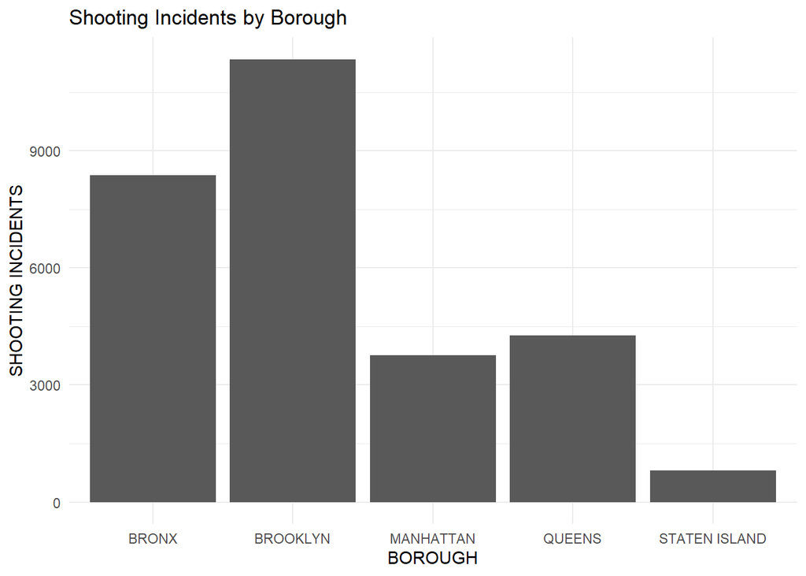

```r
borough_data <- NYPD_Shooting_Data %>%
  group_by(Borough) %>%
  summarize(Incident = n())


ggplot(borough_data, aes(x = Borough, y = Incident)) +
  geom_bar(stat="Identity") +
  ggtitle("Shooting Incidents by Borough") +
  xlab("BOROUGH") + ylab("SHOOTING INCIDENTS") +
  theme_minimal()
```

Next lets see this data broken down further by time.

```r
borough_data_over_time <- NYPD_Shooting_Data %>%
    group_by(Year, Month, Borough) %>%
    summarize(Incident = n())
```

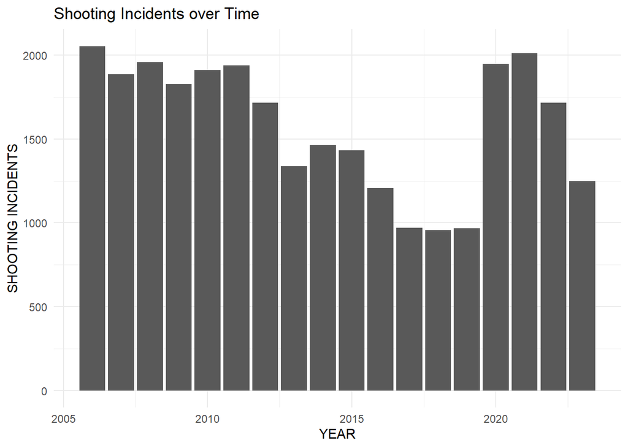

```r
ggplot(borough_data_over_time, aes(x = Year, y = Incident)) +
  geom_bar(stat="Identity") +
  ggtitle("Shooting Incidents over Time") +
  xlab("YEAR") + ylab("SHOOTING INCIDENTS") +
  theme_minimal()
```

### Conclusions from Data

From the data we can conclude that there are more shootings in certain neighborhoods than others. This does not paint a full picture however, as we do not have the data for how many people there are in each Borough, so we cant normalize this information and get an accurate number of shootings relative to the population.

Next we see the shooting incidents by year. Here we can see that there is a spike around 2020, with gradual decline after. We can guess at the reasons, from COVID lock downs, political protests, and perhaps others, but without more data these are just assumptions.

### Biases in the data

Biases are inherent in data. We all have biases both conscious or unconscious. With regards to the NYPD shooting incident data, biases can be from multiple places. In my view these can be racial bias, looking at perp and victim data there were many races and unconscious bias may have affected how a person views that data. Another kind of bias could be distrust of police or government. This could feed a bias against the data source. A third kind I felt may have an affect was a bias around firearms in civilian hands. This could also color how one views the data.